# homework1

Homework 1

1. Ages

```python
ages = [13, 15, 16, 16, 19, 20, 20, 21, 22, 22, 23, 25, 25, 25, 30, 33,
33, 33, 33, 35, 35, 36, 40, 45, 46, 52, 70]
```

```python
import statistics as stat
mean = stat.mean(ages)
median = stat.median(ages)
mode = stat.mode(ages)

print(f"(a) mean: {round(mean, 2)}, median: {median}, mode: {mode}")
```

```
(a) mean: 29.74, median: 25, mode: 33
```

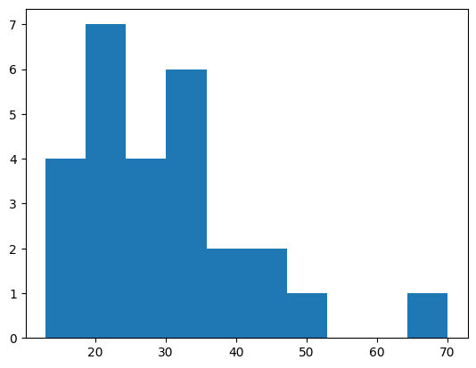

```python
from matplotlib import pyplot as plt
plt.hist(ages)
plt.show()
```

```python
# Five-number summary
minimum = min(ages)
median_index = len(ages) // 2
q1 = stat.median(ages[0:median_index])
q2 = median
q3 = stat.median(ages[median_index:-1])
maximum = max(ages)

print("(d)")
print("Five-number summary:")
print(f"Min: {minimum}")
print(f"Q1: {q1}")
print(f"Q2: {q2}")
print(f"Q3: {q3}")
print(f"Max: {maximum}")
```

```
(d)
Five-number summary:
Min: 13
Q1: 20
Q2: 25
Q3: 35
Max: 70
```

(e)

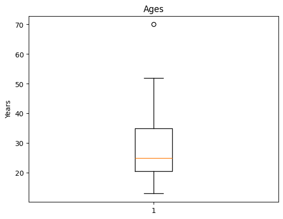

```python
plt.boxplot(ages)
plt.title("Ages")
plt.ylabel("Years")
plt.show()
```

2. Hitters

```python
import pandas as pd
Hitters = pd.read_csv('../data/Hitters.csv')
Hitters
```

|  | AtBat | Hits | HmRun | Runs | RBI | Walks | Years | CAtBat | CHits | CHmRun | CRuns | CRBI | CWalks | League | Division | PutOuts | Assists | Errors | Salary | NewLeague |
| --- | --- | --- | --- | --- | --- | --- | --- | --- | --- | --- | --- | --- | --- | --- | --- | --- | --- | --- | --- | --- |
| 0 | 293 | 66 | 1 | 30 | 29 | 14 | 1 | 293 | 66 | 1 | 30 | 29 | 14 | A | E | 446 | 33 | 20 | NaN | A |
| 1 | 315 | 81 | 7 | 24 | 38 | 39 | 14 | 3449 | 835 | 69 | 321 | 414 | 375 | N | W | 632 | 43 | 10 | 475.0 | N |
| 2 | 479 | 130 | 18 | 66 | 72 | 76 | 3 | 1624 | 457 | 63 | 224 | 266 | 263 | A | W | 880 | 82 | 14 | 480.0 | A |
| 3 | 496 | 141 | 20 | 65 | 78 | 37 | 11 | 5628 | 1575 | 225 | 828 | 838 | 354 | N | E | 200 | 11 | 3 | 500.0 | N |
| 4 | 321 | 87 | 10 | 39 | 42 | 30 | 2 | 396 | 101 | 12 | 48 | 46 | 33 | N | E | 805 | 40 | 4 | 91.5 | N |
| ... | ... | ... | ... | ... | ... | ... | ... | ... | ... | ... | ... | ... | ... | ... | ... | ... | ... | ... | ... | ... |
| 317 | 497 | 127 | 7 | 65 | 48 | 37 | 5 | 2703 | 806 | 32 | 379 | 311 | 138 | N | E | 325 | 9 | 3 | 700.0 | N |
| 318 | 492 | 136 | 5 | 76 | 50 | 94 | 12 | 5511 | 1511 | 39 | 897 | 451 | 875 | A | E | 313 | 381 | 20 | 875.0 | A |
| 319 | 475 | 126 | 3 | 61 | 43 | 52 | 6 | 1700 | 433 | 7 | 217 | 93 | 146 | A | W | 37 | 113 | 7 | 385.0 | A |
| 320 | 573 | 144 | 9 | 85 | 60 | 78 | 8 | 3198 | 857 | 97 | 470 | 420 | 332 | A | E | 1314 | 131 | 12 | 960.0 | A |
| 321 | 631 | 170 | 9 | 77 | 44 | 31 | 11 | 4908 | 1457 | 30 | 775 | 357 | 249 | A | W | 408 | 4 | 3 | 1000.0 | A |

322 rows × 20 columns

```python
num_rows, num_col = Hitters.shape
print(f"Rows: {num_rows}")
print(f"Columns: {num_col}")
```

```
Rows: 322
Columns: 20
```

The years of the data set are 1986 and 1987. HmRun is home runs for the 1986 season and CHmRun is total career home runs.

```python
# 2c
# Median value of each numeric variable
print(Hitters.median(numeric_only=True))
```

```
AtBat       379.5
Hits         96.0
HmRun         8.0
Runs         48.0
RBI          44.0
Walks        35.0
Years         6.0
CAtBat     1928.0
CHits       508.0
CHmRun       37.5
CRuns       247.0
CRBI        220.5
CWalks      170.5
PutOuts     212.0
Assists      39.5
Errors        6.0
Salary      425.0
dtype: float64
```

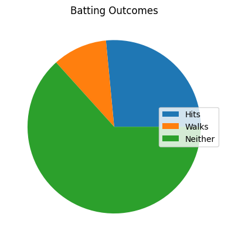

```python
# Calculate batting outcomes
total_bats = Hitters.AtBat.sum()
total_hits = Hitters.Hits.sum()
total_walks = Hitters.Walks.sum()

# Convert to percentages
walks = total_walks/total_bats * 100
hits = total_hits/total_bats * 100
neither = 100 - hits - walks
percents = [hits, walks, neither]

# Create pie chart
types = ["Hits", "Walks", "Neither"]
plt.pie(percents)
plt.title("Batting Outcomes")
plt.legend(types, loc="right")
plt.show()
```

```python
missing_rows = Hitters.Salary.isnull().sum()
print(f"Rows missing Salary data: {missing_rows}")
```

```
Rows missing Salary data: 59
```

The players missing salary data may be new players, or their salaries might not be publicly available.

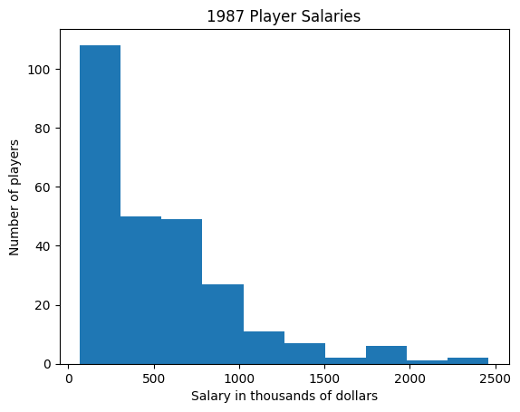

```python
plt.hist(Hitters.Salary)
plt.title("1987 Player Salaries")
plt.xlabel("Salary in thousands of dollars")
plt.ylabel("Number of players")
plt.show()
```

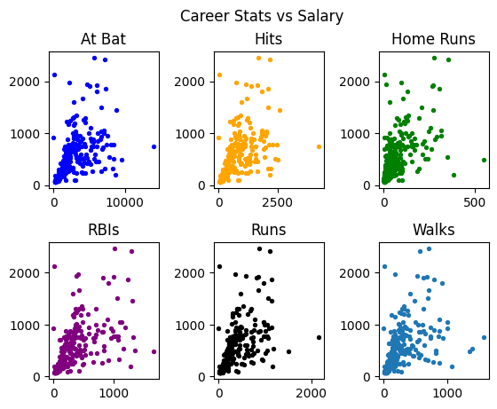

```python
# point size
size=8

plt.subplot(2,3,1)
plt.scatter(Hitters.CAtBat, Hitters.Salary, s=size, c='b')
plt.title("At Bat")
plt.subplot(2,3,2)
plt.scatter(Hitters.CHits, Hitters.Salary, s=size, c='orange')
plt.title("Hits")
plt.subplot(2,3,3)
plt.scatter(Hitters.CHmRun, Hitters.Salary, s=size, c='g')
plt.title("Home Runs")
plt.subplot(2,3,4)
plt.scatter(Hitters.CRBI, Hitters.Salary, s=size, c='purple')
plt.title("RBIs")
plt.subplot(2,3,5)
plt.scatter(Hitters.CRuns, Hitters.Salary, s=size, c='black')
plt.title("Runs")
plt.subplot(2,3,6)
plt.scatter(Hitters.CWalks, Hitters.Salary, s=size)
plt.title("Walks")
plt.suptitle("Career Stats vs Salary")
plt.subplots_adjust(wspace=0.5, hspace=0.4)
plt.show()
```

```python
# 2h
div_mean_sal = Hitters.groupby("Division")["Salary"].mean()
print(f"Mean Salary:\n{div_mean_sal}")
```

```
Mean Salary:
Division
E    624.271364
W    450.876873
Name: Salary, dtype: float64
```

```python
div_tot_sal = Hitters.groupby("Division")["Salary"].sum()
print(f"Mean Salary:\n{div_tot_sal}")
print(f"Division E spends more on salaries by ${round(div_tot_sal.E - div_tot_sal.W)}")
```

```
Mean Salary:
Division
E    80531.006
W    60417.501
Name: Salary, dtype: float64
Division E spends more on salaries by $20114
```

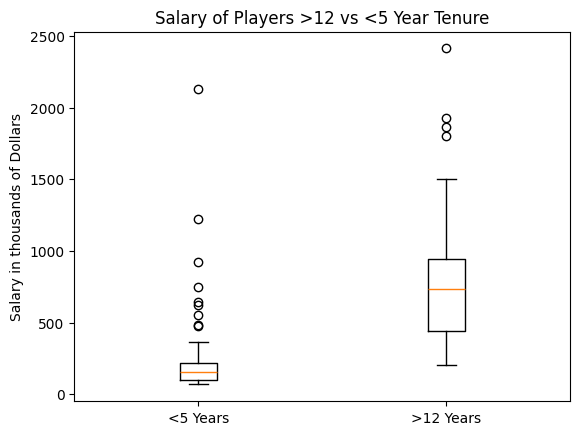

```python
# 2i
sal5 =  Hitters[Hitters["Years"] < 5]["Salary"].dropna()
sal12 = Hitters[Hitters["Years"] > 12]["Salary"].dropna()

plt.title("Salary of Players >12 vs <5 Year Tenure")
plt.boxplot([sal5, sal12], tick_labels=["<5 Years", ">12 Years"])
plt.ylabel("Salary in thousands of Dollars")
plt.show()
```

The players with over 12 years of tenure make much more on average than those playing for less than 5 years. The minimum value for the over 12s is greather than the average value for under 5s.

```python
# 2j
Hitters["CBatAvg"] = Hitters["CHits"] / Hitters["CAtBat"]
max = Hitters["CBatAvg"].max()
print(Hitters[Hitters["CBatAvg"] == max])
```

```
     AtBat  Hits  HmRun  Runs  RBI  Walks  Years  CAtBat  CHits  CHmRun  ...  \
313    580   207      8   107   71    105      5    2778    978      32  ...

     CRBI  CWalks  League Division PutOuts  Assists  Errors  Salary  \
313   322     417       A        E     121      267      19  1600.0

     NewLeague   CBatAvg
313          A  0.352052

[1 rows x 21 columns]
```

Player 313 has the highest batting average. He is in league A, division E, has a Salary of $1,600,000, and a batting average of 0.352

```python
five_highest = Hitters.nlargest(5, "CBatAvg")
print(five_highest)
```

```
     AtBat  Hits  HmRun  Runs  RBI  Walks  Years  CAtBat  CHits  CHmRun  ...  \
313    580   207      8   107   71    105      5    2778    978      32  ...
82     677   238     31   117  113     53      5    2223    737      93  ...
290    642   211     14   107   59     52      5    2364    770      27  ...
176    181    58      6    34   23     22      1     181     58       6  ...
52      19     7      0     1    2      1      4      41     13       1  ...

     CRBI  CWalks  League Division PutOuts  Assists  Errors  Salary  \
313   322     417       A        E     121      267      19  1600.0
82    401     171       A        E    1377      100       6  1975.0
290   230     193       N        W     337       19       4   740.0
176    23      22       N        W      88        0       3    86.5
52      4       4       A        E       0        0       0     NaN

     NewLeague   CBatAvg
313          A  0.352052
82           A  0.331534
290          N  0.325719
176          N  0.320442
52           A  0.317073

[5 rows x 21 columns]
```

(a) If the sample size n is extremely large and the number of predictors p is small, then an flexible model would perform better because the large sample size prevents overfitting and the relationship might be non-linear.

(b) If the number of predictors is large and the number of observations is small, then an inflexible model would perform better because the small sample size will have more randomness in the data.

(c) If the relationship between predictor and response is highly non linear, then a flexible model would perform better because it would fit the data better than if the wrong non-linear relationship was chosen.

(d) If the variance of the error is exteremely high, then an inflexible model will perform better. With high variance, a flexible model would be prone to overfitting.

(a) Regression (SAT score is quantitative), Inference (since we want to know which factors influence SAT scores), n is 600 and p is 3.

(b) Classification (readmissited or not readmitted), Inference (since we want to know which factors influence readmission), n is 2,000 and p is 5.

(c) Classification (succeed or fail), Prediction (we only want to know if the campaign will succeed), n is 45, p is 11.

(d) Regression (electricity consumption is quantitative), Prediction (we only want the estimated consumption), n is 365, p is 3.